# Project_9_NLP_new

## Twitter US Airline Sentiment - Problem Statement

### Background and Context:

Twitter possesses 330 million monthly active users, which allows businesses to reach a broad population and connect with customers without intermediaries. On the other hand, there’s so much information that it’s difficult for brands to quickly detect negative social mentions that could harm their business.

That's why sentiment analysis/classification, which involves monitoring emotions in conversations on social media platforms, has become a key strategy in social media marketing.

Listening to how customers feel about the product/service on Twitter allows companies to understand their audience, keep on top of what’s being said about their brand and their competitors, and discover new trends in the industry.

### Data Description:

A sentiment analysis job about the problems of each major U.S. airline. Twitter data was scraped from February of 2015 and contributors were asked to first classify positive, negative, and neutral tweets, followed by categorizing negative reasons (such as "late flight" or "rude service").

#### Dataset:

The dataset has the following columns:

- tweet_id
- airline_sentiment
- airline_sentiment_confidence
- negativereason
- negativereason_confidence
- airline
- airline_sentiment_gold
- name
- negativereason_gold
- retweet_count
- text
- tweet_coord
- tweet_created
- tweet_location
- user_timezone

```python
#!pip install contractions
#!pip install wordcloud
```

```python
# install and import necessary libraries.
# Library to suppress warnings or deprecation notes
import warnings

warnings.filterwarnings("ignore")


import random
import seaborn as sns                                                   # Used for plotting
from collections import Counter

sns.set()

import re, string, unicodedata                          # Import Regex, string and unicodedata.
import contractions                                     # Import contractions library.
from bs4 import BeautifulSoup                           # Import BeautifulSoup.

import numpy as np                                      # Import numpy.
import pandas as pd                                     # Import pandas.
import nltk                                             # Import Natural Language Tool-Kit.

nltk.download('stopwords')                              # Download Stopwords.
nltk.download('punkt')
nltk.download('wordnet')

from nltk.corpus import stopwords                       # Import stopwords.
from nltk.tokenize import word_tokenize, sent_tokenize  # Import Tokenizer.
from nltk.stem.wordnet import WordNetLemmatizer         # Import Lemmatizer.
import matplotlib.pyplot as plt                         # Import plt for visualization
import wordcloud as wordcloud
from sklearn.preprocessing import LabelEncoder
```

```python
def stacked_barplot(data, predictor, target):

    """
    Print the category counts and plot a stacked bar chart

    data: dataframe
    predictor: independent variable
    target: target variable
    """
    count = data[predictor].nunique()
    sorter = data[target].value_counts().index[-1]
    tab1 = pd.crosstab(data[predictor], data[target], margins=True).sort_values(
        by=sorter, ascending=False
    )
    print(tab1)
    print("-" * 120)
    tab = pd.crosstab(data[predictor], data[target], normalize="index").sort_values(
        by=sorter, ascending=False
    )
    tab.plot(kind="bar", stacked=True, figsize=(count + 5, 5))
    plt.legend(
        loc="lower left", frameon=False,
    )
    plt.legend(loc="upper left", bbox_to_anchor=(1, 1))
    plt.show()
```

```python
# function to create labeled barplots
#This function will show barplot only if the unique column values are less than 20


def labeled_barplot(data, feature, perc=False, n=None):
    """
    Barplot with percentage at the top

    data: dataframe
    feature: dataframe column
    perc: whether to display percentages instead of count (default is False)
    n: displays the top n category levels (default is None, i.e., display all levels)
    """

    total = len(data[feature])  # length of the column
    count = data[feature].nunique()
    if count < 20 :
        if n is None:
            plt.figure(figsize=(count + 1, 5))
        else:
            plt.figure(figsize=(n + 1, 5))

        plt.xticks(rotation=90, fontsize=15)
        ax = sns.countplot(
            data=data,
            x=feature,
            palette="Paired",
            order=data[feature].value_counts().index[:n].sort_values(),
        )

        for p in ax.patches:
            if perc == True:
                label = "{:.1f}%".format(
                    100 * p.get_height() / total
                )  # percentage of each class of the category
            else:
                label = p.get_height()  # count of each level of the category

            x = p.get_x() + p.get_width() / 2  # width of the plot
            y = p.get_height()  # height of the plot

            ax.annotate(
                label,
                (x, y),
                ha="center",
                va="center",
                size=12,
                xytext=(0, 5),
                textcoords="offset points",
            )  # annotate the percentage

        plt.show()  # show the plot
    else:
        print(f"The {feature} column has more than 20 unique values so will be skipped")  # f-string
```

```python
def missing_zero_values_table(df):
        zero_val = (df == 0.00).astype(int).sum(axis=0)                                            #Number of zero in each column
        mis_val = df.isnull().sum()                                                                #Missing value in each column
        mis_val_percent = 100 * df.isnull().sum() / len(df)                                        #Missing value percent accross column
        mz_table = pd.concat([zero_val, mis_val, mis_val_percent], axis=1)                         #Concatenation of above aoutput
        mz_table = mz_table.rename(
        columns = {0 : 'Zero Values', 1 : 'Missing Values', 2 : '% of Total Values'})               #Renaming of each coumn
        mz_table['Total Zero Missing Values'] = mz_table['Zero Values'] + mz_table['Missing Values']  #column having total of zero value and missing values
        mz_table['% Total Zero Missing Values'] = 100 * mz_table['Total Zero Missing Values'] / len(df) # Column having percentage of totalof zero and missing value
        mz_table['Data Type'] = df.dtypes
        mz_table = mz_table[
            mz_table.iloc[:,1] != 0].sort_values(                                                     #Selecting and sorting those column which have at not a zero value in % of Total Values column
        '% of Total Values', ascending=False).round(1)
        print ("Your selected dataframe has " + str(df.shape[1]) + " columns and " + str(df.shape[0]) + " Rows.\n"
            "There are " + str(mz_table.shape[0]) +
              " columns that have missing values.")
#         mz_table.to_excel('D:/sampledata/missing_and_zero_values.xlsx', freeze_panes=(1,0), index = False)
        return mz_table
```

#### Read the data

```python
original_df=pd.read_csv('Tweets.csv')
data = original_df.copy()
```

```python
# checking the shape of the data
print(f"There are {data.shape[0]} rows and {data.shape[1]} columns.")  # f-string
```

```
There are 14640 rows and 15 columns.
```

```python
pd.set_option('display.max_colwidth', None) # Display full dataframe information (Non-turncated Text column.)
data.head()
```

|  | tweet_id | airline_sentiment | airline_sentiment_confidence | negativereason | negativereason_confidence | airline | airline_sentiment_gold | name | negativereason_gold | retweet_count | text | tweet_coord | tweet_created | tweet_location | user_timezone |
| --- | --- | --- | --- | --- | --- | --- | --- | --- | --- | --- | --- | --- | --- | --- | --- |
| 0 | 570306133677760513 | neutral | 1.0000 | NaN | NaN | Virgin America | NaN | cairdin | NaN | 0 | @VirginAmerica What @dhepburn said. | NaN | 2015-02-24 11:35:52 -0800 | NaN | Eastern Time (US & Canada) |
| 1 | 570301130888122368 | positive | 0.3486 | NaN | 0.0000 | Virgin America | NaN | jnardino | NaN | 0 | @VirginAmerica plus you've added commercials to the experience... tacky. | NaN | 2015-02-24 11:15:59 -0800 | NaN | Pacific Time (US & Canada) |
| 2 | 570301083672813571 | neutral | 0.6837 | NaN | NaN | Virgin America | NaN | yvonnalynn | NaN | 0 | @VirginAmerica I didn't today... Must mean I need to take another trip! | NaN | 2015-02-24 11:15:48 -0800 | Lets Play | Central Time (US & Canada) |
| 3 | 570301031407624196 | negative | 1.0000 | Bad Flight | 0.7033 | Virgin America | NaN | jnardino | NaN | 0 | @VirginAmerica it's really aggressive to blast obnoxious "entertainment" in your guests' faces &amp; they have little recourse | NaN | 2015-02-24 11:15:36 -0800 | NaN | Pacific Time (US & Canada) |
| 4 | 570300817074462722 | negative | 1.0000 | Can't Tell | 1.0000 | Virgin America | NaN | jnardino | NaN | 0 | @VirginAmerica and it's a really big bad thing about it | NaN | 2015-02-24 11:14:45 -0800 | NaN | Pacific Time (US & Canada) |

#### Dropping id and name

```python
#The tweet_id, name column can be dropped as they are identifiers and are not useful here
data.drop(['tweet_id', 'name'],axis=1,inplace=True)
data.shape
```

```
(14640, 13)
```

```python
# Let's look at the statistical summary of the data
data.describe(include="all").T
```

|  | count | unique | top | freq | mean | std | min | 25% | 50% | 75% | max |
| --- | --- | --- | --- | --- | --- | --- | --- | --- | --- | --- | --- |
| airline_sentiment | 14640 | 3 | negative | 9178 | NaN | NaN | NaN | NaN | NaN | NaN | NaN |
| airline_sentiment_confidence | 14640.0 | NaN | NaN | NaN | 0.900169 | 0.16283 | 0.335 | 0.6923 | 1.0 | 1.0 | 1.0 |
| negativereason | 9178 | 10 | Customer Service Issue | 2910 | NaN | NaN | NaN | NaN | NaN | NaN | NaN |
| negativereason_confidence | 10522.0 | NaN | NaN | NaN | 0.638298 | 0.33044 | 0.0 | 0.3606 | 0.6706 | 1.0 | 1.0 |
| airline | 14640 | 6 | United | 3822 | NaN | NaN | NaN | NaN | NaN | NaN | NaN |
| airline_sentiment_gold | 40 | 3 | negative | 32 | NaN | NaN | NaN | NaN | NaN | NaN | NaN |
| negativereason_gold | 32 | 13 | Customer Service Issue | 12 | NaN | NaN | NaN | NaN | NaN | NaN | NaN |
| retweet_count | 14640.0 | NaN | NaN | NaN | 0.08265 | 0.745778 | 0.0 | 0.0 | 0.0 | 0.0 | 44.0 |
| text | 14640 | 14427 | @united thanks | 6 | NaN | NaN | NaN | NaN | NaN | NaN | NaN |
| tweet_coord | 1019 | 832 | [0.0, 0.0] | 164 | NaN | NaN | NaN | NaN | NaN | NaN | NaN |
| tweet_created | 14640 | 14247 | 2015-02-24 09:54:34 -0800 | 5 | NaN | NaN | NaN | NaN | NaN | NaN | NaN |
| tweet_location | 9907 | 3081 | Boston, MA | 157 | NaN | NaN | NaN | NaN | NaN | NaN | NaN |
| user_timezone | 9820 | 85 | Eastern Time (US & Canada) | 3744 | NaN | NaN | NaN | NaN | NaN | NaN | NaN |

- There are 3 types of airline sentiments
- There are 6 unique airlines
- There are 85 unique time zones
- There are 10 unique neagative reasons listed
- There are many columns that have nulls
- There are 3,081 unique tweet locations

```python
# checking column datatypes
data.info()
```

```
<class 'pandas.core.frame.DataFrame'>
RangeIndex: 14640 entries, 0 to 14639
Data columns (total 13 columns):
 #   Column                        Non-Null Count  Dtype
---  ------                        --------------  -----
 0   airline_sentiment             14640 non-null  object
 1   airline_sentiment_confidence  14640 non-null  float64
 2   negativereason                9178 non-null   object
 3   negativereason_confidence     10522 non-null  float64
 4   airline                       14640 non-null  object
 5   airline_sentiment_gold        40 non-null     object
 6   negativereason_gold           32 non-null     object
 7   retweet_count                 14640 non-null  int64
 8   text                          14640 non-null  object
 9   tweet_coord                   1019 non-null   object
 10  tweet_created                 14640 non-null  object
 11  tweet_location                9907 non-null   object
 12  user_timezone                 9820 non-null   object
dtypes: float64(2), int64(1), object(10)
memory usage: 1.5+ MB
```

- Most of the columns are of data type object.
- we can look into making airline sentiment categorical

#### Checking for Duplicate rows and dropping them

```python
# Check  for dupliucate values
data.duplicated().sum()
print(f"There are {data.duplicated().sum()} duplicate rows.")  # f-string
```

```
There are 36 duplicate rows.
```

```python
#Dropping duplicate rows
data.drop_duplicates(keep = 'first', inplace=True)
data.shape
```

```
(14604, 13)
```

#### Setting Date columns

```python
year=[]
month=[]
date=[]
hour=[]
for x in data['tweet_created']:
    year.append(int(x.split("-")[0]))                                          #extraction of year from date column and appending into list
    month.append(int(x.split("-")[1]))                                         #extraction of month from date column and appending into list
    date.append(int(x.split("-")[2].split(" ")[0]))                            #extraction of date of the month from date column and appending into list
    hour.append(int(x.split("-")[2].split(" ")[1].split(":")[0]))              #extraction of hour of that day from date column and appending into list

data['year']=year
data['month']=month
data['dates']=date
data['hour']=hour
data.head()
```

|  | airline_sentiment | airline_sentiment_confidence | negativereason | negativereason_confidence | airline | airline_sentiment_gold | negativereason_gold | retweet_count | text | tweet_coord | tweet_created | tweet_location | user_timezone | year | month | dates | hour |
| --- | --- | --- | --- | --- | --- | --- | --- | --- | --- | --- | --- | --- | --- | --- | --- | --- | --- |
| 0 | neutral | 1.0000 | NaN | NaN | Virgin America | NaN | NaN | 0 | @VirginAmerica What @dhepburn said. | NaN | 2015-02-24 11:35:52 -0800 | NaN | Eastern Time (US & Canada) | 2015 | 2 | 24 | 11 |
| 1 | positive | 0.3486 | NaN | 0.0000 | Virgin America | NaN | NaN | 0 | @VirginAmerica plus you've added commercials to the experience... tacky. | NaN | 2015-02-24 11:15:59 -0800 | NaN | Pacific Time (US & Canada) | 2015 | 2 | 24 | 11 |
| 2 | neutral | 0.6837 | NaN | NaN | Virgin America | NaN | NaN | 0 | @VirginAmerica I didn't today... Must mean I need to take another trip! | NaN | 2015-02-24 11:15:48 -0800 | Lets Play | Central Time (US & Canada) | 2015 | 2 | 24 | 11 |
| 3 | negative | 1.0000 | Bad Flight | 0.7033 | Virgin America | NaN | NaN | 0 | @VirginAmerica it's really aggressive to blast obnoxious "entertainment" in your guests' faces &amp; they have little recourse | NaN | 2015-02-24 11:15:36 -0800 | NaN | Pacific Time (US & Canada) | 2015 | 2 | 24 | 11 |
| 4 | negative | 1.0000 | Can't Tell | 1.0000 | Virgin America | NaN | NaN | 0 | @VirginAmerica and it's a really big bad thing about it | NaN | 2015-02-24 11:14:45 -0800 | NaN | Pacific Time (US & Canada) | 2015 | 2 | 24 | 11 |

#### Looking at missing data

```python
data.isnull().sum(axis=0)
```

```
airline_sentiment                   0
airline_sentiment_confidence        0
negativereason                   5445
negativereason_confidence        4101
airline                             0
airline_sentiment_gold          14564
negativereason_gold             14572
retweet_count                       0
text                                0
tweet_coord                     13589
tweet_created                       0
tweet_location                   4723
user_timezone                    4814
year                                0
month                               0
dates                               0
hour                                0
dtype: int64
```

There are many null values, we can run the function below to get more information about them

```python
missing_zero_values_table(data)
```

```
Your selected dataframe has 17 columns and 14604 Rows.
There are 7 columns that have missing values.
```

|  | Zero Values | Missing Values | % of Total Values | Total Zero Missing Values | % Total Zero Missing Values | Data Type |
| --- | --- | --- | --- | --- | --- | --- |
| negativereason_gold | 0 | 14572 | 99.8 | 14572 | 99.8 | object |
| airline_sentiment_gold | 0 | 14564 | 99.7 | 14564 | 99.7 | object |
| tweet_coord | 0 | 13589 | 93.0 | 13589 | 93.0 | object |
| negativereason | 0 | 5445 | 37.3 | 5445 | 37.3 | object |
| user_timezone | 0 | 4814 | 33.0 | 4814 | 33.0 | object |
| tweet_location | 0 | 4723 | 32.3 | 4723 | 32.3 | object |
| negativereason_confidence | 1344 | 4101 | 28.1 | 5445 | 37.3 | float64 |

- There are many columns that are null.
- negativereason_gold, airline_sentiment_gold, tweet_coord have more than 90% of the rows as missing
- negativereason, user_timezone, tweet_location, negativereason_confidence have around 30% missing values
- we can drop the columns with high missing values

```python
#Drop the column which have got too many missing values or does not relevent information
data.drop(['negativereason_gold', 'airline_sentiment_gold','tweet_coord'],axis=1,inplace=True)
data.shape
```

```
(14604, 14)
```

#### Looking at unique values

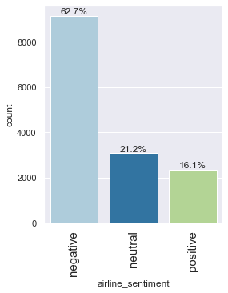

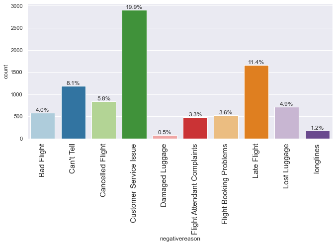

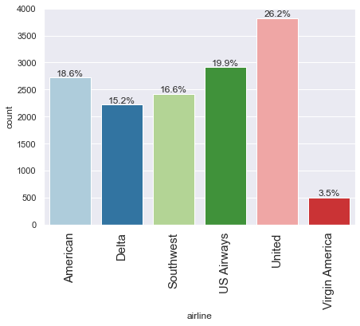

```
The text column has more than 20 unique values so will be skipped
The tweet_created column has more than 20 unique values so will be skipped
The tweet_location column has more than 20 unique values so will be skipped
The user_timezone column has more than 20 unique values so will be skipped
```

```python
#For every column in the dataframe that has a categorical or object datatype, show distribution plot
#The unique values will be shown only if they are less than 20
for colname in data.columns[data.dtypes == 'category'] | data.columns[data.dtypes == 'object']:
    labeled_barplot(data, colname, perc=True)
```

- There are 3 airline sentiments. 63% are negative, 21% are neutral and only 16% are positive
- The highest negativereason is 'Customer Service Issue' at 20%, Followed by 'Late Flight' at 11%.
- Damaged Luggage and long lines were the least reason for negative sentiment
- There are 6 airlines. United has the most tweets with 26%. Followed by US Airways, American, Southwest and Delta. Virgin America has the least with only 3.5%

#### Number of characters and words in tweets

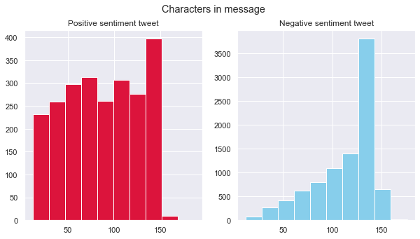

```python
#Number of characters in tweets
fig,(ax1,ax2) = plt.subplots(1,2,figsize=(10,5))
tweet_len = data[data['airline_sentiment']=='positive']['text'].str.len()
ax1.hist(tweet_len,color='crimson')
ax1.set_title('Positive sentiment tweet')
tweet_len = data[data['airline_sentiment']=='negative']['text'].str.len()
ax2.hist(tweet_len,color='skyblue')
ax2.set_title('Negative sentiment tweet')
fig.suptitle('Characters in message')
```

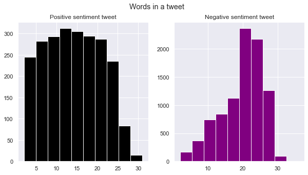

```python
#Number of words in a tweet
fig,(ax1,ax2) = plt.subplots(1,2,figsize=(10,5))
tweet_len = data[data['airline_sentiment']=='positive']['text'].str.split().map(lambda x: len(x))
ax1.hist(tweet_len, color='black')
ax1.set_title('Positive sentiment tweet')
tweet_len = data[data['airline_sentiment']=='negative']['text'].str.split().map(lambda x: len(x))
ax2.hist(tweet_len,color='purple')
ax2.set_title('Negative sentiment tweet')
fig.suptitle('Words in a tweet')
```

#### Most active hour on twitter

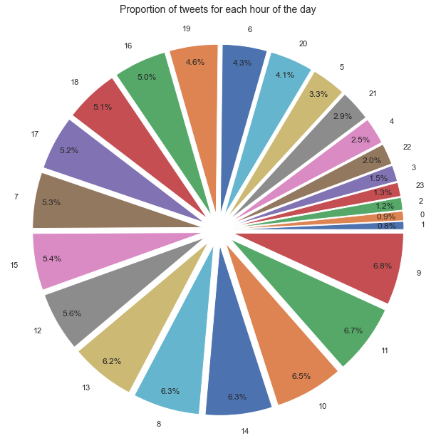

```python
#Using matplotlib
Category=data['hour'].value_counts().sort_values()
pie, ax = plt.subplots(figsize=[20,11])
labels = Category.keys()
plt.pie(x=Category, autopct="%.1f%%", explode=[0.09]*24, labels=labels, pctdistance=0.9)
plt.title("Proportion of tweets for each hour of the day", fontsize=14);
#pie.savefig("DeliveryPieChart.png")
```

- Most of the tweets were in the morning and early afternoon from 8 am to 1pm. 9 am and 11 am were the most common hours.
- Very few tweets happened late at night from 10pm to 4am.
- This could be because there are more flights in the day as compared to night.

#### Number of tweet per Day

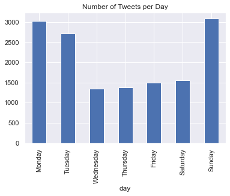

```python
data['tweet_created'] = pd.to_datetime(data['tweet_created']) # To make sure that pandas understands it's a date
plt.figsize = (16,10)

plt.title("Number of Tweets per Day")
tweet_cpt = data['tweet_created'].groupby(data['tweet_created'].dt.day_name()).count()
tweet_cpt.reindex(["Monday", "Tuesday", "Wednesday", "Thursday", "Friday", "Saturday", "Sunday"]).plot(kind="bar")    #Assigning each day of the week as index
plt.xlabel("day")
plt.show()
```

- Sunday, Monday and Tuesday have higher tweets

#### Airline sentiment per Airline

```
airline_sentiment  negative  neutral  positive    All
airline
All                    9159     3091      2354  14604
Southwest              1186      664       570   2420
Delta                   955      723       544   2222
United                 2633      697       492   3822
American               1941      455       327   2723
US Airways             2263      381       269   2913
Virgin America          181      171       152    504
------------------------------------------------------------------------------------------------------------------------
```

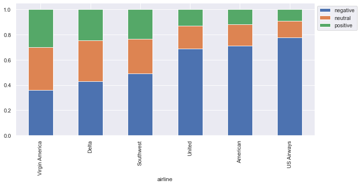

```python
stacked_barplot(data, "airline", "airline_sentiment")
```

- Virgin America, Delta and Southwest have the most positive sentiments
- United, American and USAirways have the least positive sentiments
- Consequently, United, American and USAirways have the most negative sentiments

#### Negative Reason per Airline

```
negativereason  Bad Flight  Can't Tell  Cancelled Flight  \
airline
All                    580        1190               843
United                 216         379               181
Southwest               90         159               162
American                87         198               242
Delta                   64         186                51
US Airways             104         246               189
Virgin America          19          22                18

negativereason  Customer Service Issue  Damaged Luggage  \
airline
All                               2904               74
United                             681               22
Southwest                          391               14
American                           762               12
Delta                              199               11
US Airways                         811               11
Virgin America                      60                4

negativereason  Flight Attendant Complaints  Flight Booking Problems  \
airline
All                                     480                      529
United                                  168                      144
Southwest                                38                       61
American                                 86                      130
Delta                                    60                       44
US Airways                              123                      122
Virgin America                            5                       28

negativereason  Late Flight  Lost Luggage  longlines   All
airline
All                    1660           721        178  9159
United                  525           269         48  2633
Southwest               152            90         29  1186
American                244           146         34  1941
Delta                   269            57         14   955
US Airways              453           154         50  2263
Virgin America           17             5          3   181
------------------------------------------------------------------------------------------------------------------------
```

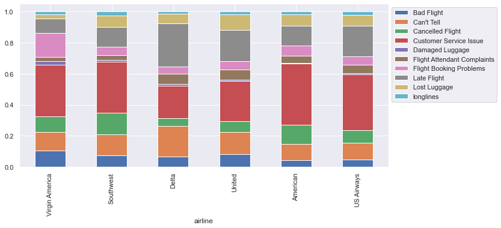

```python
stacked_barplot(data, "airline", "negativereason")
```

#### Tweet with the highest retweet count

```python
data.retweet_count.value_counts()
```

```
0     13838
1       639
2        66
3        22
4        17
5         5
7         3
6         3
22        2
8         1
32        1
28        1
9         1
18        1
11        1
31        1
15        1
44        1
Name: retweet_count, dtype: int64
```

```python
data[data['retweet_count'] == 44]
```

|  | airline_sentiment | airline_sentiment_confidence | negativereason | negativereason_confidence | airline | retweet_count | text | tweet_created | tweet_location | user_timezone | year | month | dates | hour |
| --- | --- | --- | --- | --- | --- | --- | --- | --- | --- | --- | --- | --- | --- | --- |
| 11596 | negative | 1.0 | Late Flight | 1.0 | US Airways | 44 | @USAirways 5 hr flight delay and a delay when we land . Is that even real life ? Get me off this plane , I wanna go home 👠👠👠 (3 heel clicks) | 2015-02-17 20:06:21-08:00 | NaN | Eastern Time (US & Canada) | 2015 | 2 | 17 | 20 |

```python
print(data.iloc[data['retweet_count'].idxmax()]['text'])
```

```
@USAirways 5 hr flight delay and a delay when we land . Is that even real life ? Get me off this plane , I wanna go home 👠👠👠 (3 heel clicks)
```

### Text Preprocessing

- Remove html tags.
- Replace contractions in string. (e.g. replace I'm --> I am) and so on.\
- Remove numbers.
- Tokenization
- To remove Stopwords.
- Lemmatized data
- We have used the NLTK library to tokenize words, remove stopwords and lemmatize the remaining words

```python
data.tail()
```

|  | airline_sentiment | airline_sentiment_confidence | negativereason | negativereason_confidence | airline | retweet_count | text | tweet_created | tweet_location | user_timezone | year | month | dates | hour |
| --- | --- | --- | --- | --- | --- | --- | --- | --- | --- | --- | --- | --- | --- | --- |
| 14635 | positive | 0.3487 | NaN | 0.0000 | American | 0 | @AmericanAir thank you we got on a different flight to Chicago. | 2015-02-22 12:01:01-08:00 | NaN | NaN | 2015 | 2 | 22 | 12 |
| 14636 | negative | 1.0000 | Customer Service Issue | 1.0000 | American | 0 | @AmericanAir leaving over 20 minutes Late Flight. No warnings or communication until we were 15 minutes Late Flight. That's called shitty customer svc | 2015-02-22 11:59:46-08:00 | Texas | NaN | 2015 | 2 | 22 | 11 |
| 14637 | neutral | 1.0000 | NaN | NaN | American | 0 | @AmericanAir Please bring American Airlines to #BlackBerry10 | 2015-02-22 11:59:15-08:00 | Nigeria,lagos | NaN | 2015 | 2 | 22 | 11 |
| 14638 | negative | 1.0000 | Customer Service Issue | 0.6659 | American | 0 | @AmericanAir you have my money, you change my flight, and don't answer your phones! Any other suggestions so I can make my commitment?? | 2015-02-22 11:59:02-08:00 | New Jersey | Eastern Time (US & Canada) | 2015 | 2 | 22 | 11 |
| 14639 | neutral | 0.6771 | NaN | 0.0000 | American | 0 | @AmericanAir we have 8 ppl so we need 2 know how many seats are on the next flight. Plz put us on standby for 4 people on the next flight? | 2015-02-22 11:58:51-08:00 | dallas, TX | NaN | 2015 | 2 | 22 | 11 |

#### Removal of html tags

```python
# Removal of the http link using Regular Expression.
for i, row in data.iterrows():
    clean_tweet = re.sub(r"http\S+", "", data.at[i, 'text'])
    data.at[i,'text'] = clean_tweet
data.head()
```

|  | airline_sentiment | airline_sentiment_confidence | negativereason | negativereason_confidence | airline | retweet_count | text | tweet_created | tweet_location | user_timezone | year | month | dates | hour |
| --- | --- | --- | --- | --- | --- | --- | --- | --- | --- | --- | --- | --- | --- | --- |
| 0 | neutral | 1.0000 | NaN | NaN | Virgin America | 0 | @VirginAmerica What @dhepburn said. | 2015-02-24 11:35:52-08:00 | NaN | Eastern Time (US & Canada) | 2015 | 2 | 24 | 11 |
| 1 | positive | 0.3486 | NaN | 0.0000 | Virgin America | 0 | @VirginAmerica plus you've added commercials to the experience... tacky. | 2015-02-24 11:15:59-08:00 | NaN | Pacific Time (US & Canada) | 2015 | 2 | 24 | 11 |
| 2 | neutral | 0.6837 | NaN | NaN | Virgin America | 0 | @VirginAmerica I didn't today... Must mean I need to take another trip! | 2015-02-24 11:15:48-08:00 | Lets Play | Central Time (US & Canada) | 2015 | 2 | 24 | 11 |
| 3 | negative | 1.0000 | Bad Flight | 0.7033 | Virgin America | 0 | @VirginAmerica it's really aggressive to blast obnoxious "entertainment" in your guests' faces &amp; they have little recourse | 2015-02-24 11:15:36-08:00 | NaN | Pacific Time (US & Canada) | 2015 | 2 | 24 | 11 |
| 4 | negative | 1.0000 | Can't Tell | 1.0000 | Virgin America | 0 | @VirginAmerica and it's a really big bad thing about it | 2015-02-24 11:14:45-08:00 | NaN | Pacific Time (US & Canada) | 2015 | 2 | 24 | 11 |

#### De contraction of words

```python
def replace_contractions(text):
    """Replace contractions in string of text"""
    return contractions.fix(text)

# Perform the above operation over all the rows of tweet column of the dataframe.
for i, row in data.iterrows():
    content = data.at[i, 'text']
    clean_content = replace_contractions(content)
    data.at[i,'text'] = clean_content
data.head()
```

|  | airline_sentiment | airline_sentiment_confidence | negativereason | negativereason_confidence | airline | retweet_count | text | tweet_created | tweet_location | user_timezone | year | month | dates | hour |
| --- | --- | --- | --- | --- | --- | --- | --- | --- | --- | --- | --- | --- | --- | --- |
| 0 | neutral | 1.0000 | NaN | NaN | Virgin America | 0 | @VirginAmerica What @dhepburn said. | 2015-02-24 11:35:52-08:00 | NaN | Eastern Time (US & Canada) | 2015 | 2 | 24 | 11 |
| 1 | positive | 0.3486 | NaN | 0.0000 | Virgin America | 0 | @VirginAmerica plus you have added commercials to the experience... tacky. | 2015-02-24 11:15:59-08:00 | NaN | Pacific Time (US & Canada) | 2015 | 2 | 24 | 11 |
| 2 | neutral | 0.6837 | NaN | NaN | Virgin America | 0 | @VirginAmerica I did not today... Must mean I need to take another trip! | 2015-02-24 11:15:48-08:00 | Lets Play | Central Time (US & Canada) | 2015 | 2 | 24 | 11 |
| 3 | negative | 1.0000 | Bad Flight | 0.7033 | Virgin America | 0 | @VirginAmerica it is really aggressive to blast obnoxious "entertainment" in your guests' faces &amp; they have little recourse | 2015-02-24 11:15:36-08:00 | NaN | Pacific Time (US & Canada) | 2015 | 2 | 24 | 11 |
| 4 | negative | 1.0000 | Can't Tell | 1.0000 | Virgin America | 0 | @VirginAmerica and it is a really big bad thing about it | 2015-02-24 11:14:45-08:00 | NaN | Pacific Time (US & Canada) | 2015 | 2 | 24 | 11 |

#### Removal of number

```python
def remove_numbers(text):
  text = re.sub(r'\d+', '', text)
  return text

data['text'] = data['text'].apply(lambda x: remove_numbers(x))
data.head()
```

|  | airline_sentiment | airline_sentiment_confidence | negativereason | negativereason_confidence | airline | retweet_count | text | tweet_created | tweet_location | user_timezone | year | month | dates | hour |
| --- | --- | --- | --- | --- | --- | --- | --- | --- | --- | --- | --- | --- | --- | --- |
| 0 | neutral | 1.0000 | NaN | NaN | Virgin America | 0 | @VirginAmerica What @dhepburn said. | 2015-02-24 11:35:52-08:00 | NaN | Eastern Time (US & Canada) | 2015 | 2 | 24 | 11 |
| 1 | positive | 0.3486 | NaN | 0.0000 | Virgin America | 0 | @VirginAmerica plus you have added commercials to the experience... tacky. | 2015-02-24 11:15:59-08:00 | NaN | Pacific Time (US & Canada) | 2015 | 2 | 24 | 11 |
| 2 | neutral | 0.6837 | NaN | NaN | Virgin America | 0 | @VirginAmerica I did not today... Must mean I need to take another trip! | 2015-02-24 11:15:48-08:00 | Lets Play | Central Time (US & Canada) | 2015 | 2 | 24 | 11 |
| 3 | negative | 1.0000 | Bad Flight | 0.7033 | Virgin America | 0 | @VirginAmerica it is really aggressive to blast obnoxious "entertainment" in your guests' faces &amp; they have little recourse | 2015-02-24 11:15:36-08:00 | NaN | Pacific Time (US & Canada) | 2015 | 2 | 24 | 11 |
| 4 | negative | 1.0000 | Can't Tell | 1.0000 | Virgin America | 0 | @VirginAmerica and it is a really big bad thing about it | 2015-02-24 11:14:45-08:00 | NaN | Pacific Time (US & Canada) | 2015 | 2 | 24 | 11 |

#### Tokenization

```python
data['text'] = data.apply(lambda row: nltk.word_tokenize(row['text']), axis=1) # Tokenization of data
data.head()
```

|  | airline_sentiment | airline_sentiment_confidence | negativereason | negativereason_confidence | airline | retweet_count | text | tweet_created | tweet_location | user_timezone | year | month | dates | hour |
| --- | --- | --- | --- | --- | --- | --- | --- | --- | --- | --- | --- | --- | --- | --- |
| 0 | neutral | 1.0000 | NaN | NaN | Virgin America | 0 | [@, VirginAmerica, What, @, dhepburn, said, .] | 2015-02-24 11:35:52-08:00 | NaN | Eastern Time (US & Canada) | 2015 | 2 | 24 | 11 |
| 1 | positive | 0.3486 | NaN | 0.0000 | Virgin America | 0 | [@, VirginAmerica, plus, you, have, added, commercials, to, the, experience, ..., tacky, .] | 2015-02-24 11:15:59-08:00 | NaN | Pacific Time (US & Canada) | 2015 | 2 | 24 | 11 |
| 2 | neutral | 0.6837 | NaN | NaN | Virgin America | 0 | [@, VirginAmerica, I, did, not, today, ..., Must, mean, I, need, to, take, another, trip, !] | 2015-02-24 11:15:48-08:00 | Lets Play | Central Time (US & Canada) | 2015 | 2 | 24 | 11 |
| 3 | negative | 1.0000 | Bad Flight | 0.7033 | Virgin America | 0 | [@, VirginAmerica, it, is, really, aggressive, to, blast, obnoxious, ``, entertainment, '', in, your, guests, ', faces, &, amp, ;, they, have, little, recourse] | 2015-02-24 11:15:36-08:00 | NaN | Pacific Time (US & Canada) | 2015 | 2 | 24 | 11 |
| 4 | negative | 1.0000 | Can't Tell | 1.0000 | Virgin America | 0 | [@, VirginAmerica, and, it, is, a, really, big, bad, thing, about, it] | 2015-02-24 11:14:45-08:00 | NaN | Pacific Time (US & Canada) | 2015 | 2 | 24 | 11 |

#### Remove non ascii characters

```python
def remove_non_ascii(words):
    """Remove non-ASCII characters from list of tokenized words"""
    new_words = []                        # Create empty list to store pre-processed words.
    for word in words:
        new_word = unicodedata.normalize('NFKD', word).encode('ascii', 'ignore').decode('utf-8', 'ignore')
        new_words.append(new_word)        # Append processed words to new list.
    return new_words
```

```python
data['text'] = data['text'].apply(lambda x: remove_non_ascii(x))
data.head()
```

|  | airline_sentiment | airline_sentiment_confidence | negativereason | negativereason_confidence | airline | retweet_count | text | tweet_created | tweet_location | user_timezone | year | month | dates | hour |
| --- | --- | --- | --- | --- | --- | --- | --- | --- | --- | --- | --- | --- | --- | --- |
| 0 | neutral | 1.0000 | NaN | NaN | Virgin America | 0 | [@, VirginAmerica, What, @, dhepburn, said, .] | 2015-02-24 11:35:52-08:00 | NaN | Eastern Time (US & Canada) | 2015 | 2 | 24 | 11 |
| 1 | positive | 0.3486 | NaN | 0.0000 | Virgin America | 0 | [@, VirginAmerica, plus, you, have, added, commercials, to, the, experience, ..., tacky, .] | 2015-02-24 11:15:59-08:00 | NaN | Pacific Time (US & Canada) | 2015 | 2 | 24 | 11 |
| 2 | neutral | 0.6837 | NaN | NaN | Virgin America | 0 | [@, VirginAmerica, I, did, not, today, ..., Must, mean, I, need, to, take, another, trip, !] | 2015-02-24 11:15:48-08:00 | Lets Play | Central Time (US & Canada) | 2015 | 2 | 24 | 11 |
| 3 | negative | 1.0000 | Bad Flight | 0.7033 | Virgin America | 0 | [@, VirginAmerica, it, is, really, aggressive, to, blast, obnoxious, ``, entertainment, '', in, your, guests, ', faces, &, amp, ;, they, have, little, recourse] | 2015-02-24 11:15:36-08:00 | NaN | Pacific Time (US & Canada) | 2015 | 2 | 24 | 11 |
| 4 | negative | 1.0000 | Can't Tell | 1.0000 | Virgin America | 0 | [@, VirginAmerica, and, it, is, a, really, big, bad, thing, about, it] | 2015-02-24 11:14:45-08:00 | NaN | Pacific Time (US & Canada) | 2015 | 2 | 24 | 11 |

#### Lowercase

```python
def to_lowercase(words):
    """Convert all characters to lowercase from list of tokenized words"""
    new_words = []                        # Create empty list to store pre-processed words.
    for word in words:
        new_word = word.lower()           # Converting to lowercase
        new_words.append(new_word)        # Append processed words to new list.
    return new_words
```

```python
data['text'] = data['text'].apply(lambda x: to_lowercase(x))
data.head()
```

|  | airline_sentiment | airline_sentiment_confidence | negativereason | negativereason_confidence | airline | retweet_count | text | tweet_created | tweet_location | user_timezone | year | month | dates | hour |
| --- | --- | --- | --- | --- | --- | --- | --- | --- | --- | --- | --- | --- | --- | --- |
| 0 | neutral | 1.0000 | NaN | NaN | Virgin America | 0 | [@, virginamerica, what, @, dhepburn, said, .] | 2015-02-24 11:35:52-08:00 | NaN | Eastern Time (US & Canada) | 2015 | 2 | 24 | 11 |
| 1 | positive | 0.3486 | NaN | 0.0000 | Virgin America | 0 | [@, virginamerica, plus, you, have, added, commercials, to, the, experience, ..., tacky, .] | 2015-02-24 11:15:59-08:00 | NaN | Pacific Time (US & Canada) | 2015 | 2 | 24 | 11 |
| 2 | neutral | 0.6837 | NaN | NaN | Virgin America | 0 | [@, virginamerica, i, did, not, today, ..., must, mean, i, need, to, take, another, trip, !] | 2015-02-24 11:15:48-08:00 | Lets Play | Central Time (US & Canada) | 2015 | 2 | 24 | 11 |
| 3 | negative | 1.0000 | Bad Flight | 0.7033 | Virgin America | 0 | [@, virginamerica, it, is, really, aggressive, to, blast, obnoxious, ``, entertainment, '', in, your, guests, ', faces, &, amp, ;, they, have, little, recourse] | 2015-02-24 11:15:36-08:00 | NaN | Pacific Time (US & Canada) | 2015 | 2 | 24 | 11 |
| 4 | negative | 1.0000 | Can't Tell | 1.0000 | Virgin America | 0 | [@, virginamerica, and, it, is, a, really, big, bad, thing, about, it] | 2015-02-24 11:14:45-08:00 | NaN | Pacific Time (US & Canada) | 2015 | 2 | 24 | 11 |

#### Removal of Punctuation

```python
def remove_punctuation(words):
    """Remove punctuation from list of tokenized words"""
    new_words = []                        # Create empty list to store pre-processed words.
    for word in words:
        new_word = re.sub(r'[^\w\s]', '', word)
        if new_word != '':
            new_words.append(new_word)    # Append processed words to new list.
    return new_words
```

```python
data['text'] = data['text'].apply(lambda x: remove_punctuation(x))
data.head()
```

|  | airline_sentiment | airline_sentiment_confidence | negativereason | negativereason_confidence | airline | retweet_count | text | tweet_created | tweet_location | user_timezone | year | month | dates | hour |
| --- | --- | --- | --- | --- | --- | --- | --- | --- | --- | --- | --- | --- | --- | --- |
| 0 | neutral | 1.0000 | NaN | NaN | Virgin America | 0 | [virginamerica, what, dhepburn, said] | 2015-02-24 11:35:52-08:00 | NaN | Eastern Time (US & Canada) | 2015 | 2 | 24 | 11 |
| 1 | positive | 0.3486 | NaN | 0.0000 | Virgin America | 0 | [virginamerica, plus, you, have, added, commercials, to, the, experience, tacky] | 2015-02-24 11:15:59-08:00 | NaN | Pacific Time (US & Canada) | 2015 | 2 | 24 | 11 |
| 2 | neutral | 0.6837 | NaN | NaN | Virgin America | 0 | [virginamerica, i, did, not, today, must, mean, i, need, to, take, another, trip] | 2015-02-24 11:15:48-08:00 | Lets Play | Central Time (US & Canada) | 2015 | 2 | 24 | 11 |
| 3 | negative | 1.0000 | Bad Flight | 0.7033 | Virgin America | 0 | [virginamerica, it, is, really, aggressive, to, blast, obnoxious, entertainment, in, your, guests, faces, amp, they, have, little, recourse] | 2015-02-24 11:15:36-08:00 | NaN | Pacific Time (US & Canada) | 2015 | 2 | 24 | 11 |
| 4 | negative | 1.0000 | Can't Tell | 1.0000 | Virgin America | 0 | [virginamerica, and, it, is, a, really, big, bad, thing, about, it] | 2015-02-24 11:14:45-08:00 | NaN | Pacific Time (US & Canada) | 2015 | 2 | 24 | 11 |

#### Removal of stopwords

```python
stopwords = stopwords.words('english')
```

```python
def remove_stopwords(words):
    """Remove stop words from list of tokenized words"""
    new_words = []                        # Create empty list to store pre-processed words.
    for word in words:
        if word not in stopwords:
            new_words.append(word)        # Append processed words to new list.
    return new_words
```

```python
data['text'] = data['text'].apply(lambda x: remove_stopwords(x))
data.head()
```

|  | airline_sentiment | airline_sentiment_confidence | negativereason | negativereason_confidence | airline | retweet_count | text | tweet_created | tweet_location | user_timezone | year | month | dates | hour |
| --- | --- | --- | --- | --- | --- | --- | --- | --- | --- | --- | --- | --- | --- | --- |
| 0 | neutral | 1.0000 | NaN | NaN | Virgin America | 0 | [virginamerica, dhepburn, said] | 2015-02-24 11:35:52-08:00 | NaN | Eastern Time (US & Canada) | 2015 | 2 | 24 | 11 |
| 1 | positive | 0.3486 | NaN | 0.0000 | Virgin America | 0 | [virginamerica, plus, added, commercials, experience, tacky] | 2015-02-24 11:15:59-08:00 | NaN | Pacific Time (US & Canada) | 2015 | 2 | 24 | 11 |
| 2 | neutral | 0.6837 | NaN | NaN | Virgin America | 0 | [virginamerica, today, must, mean, need, take, another, trip] | 2015-02-24 11:15:48-08:00 | Lets Play | Central Time (US & Canada) | 2015 | 2 | 24 | 11 |
| 3 | negative | 1.0000 | Bad Flight | 0.7033 | Virgin America | 0 | [virginamerica, really, aggressive, blast, obnoxious, entertainment, guests, faces, amp, little, recourse] | 2015-02-24 11:15:36-08:00 | NaN | Pacific Time (US & Canada) | 2015 | 2 | 24 | 11 |
| 4 | negative | 1.0000 | Can't Tell | 1.0000 | Virgin America | 0 | [virginamerica, really, big, bad, thing] | 2015-02-24 11:14:45-08:00 | NaN | Pacific Time (US & Canada) | 2015 | 2 | 24 | 11 |

#### Lemmatization

```python
lemmatizer = WordNetLemmatizer()
def lemmatize_list(words):
    new_words = []
    for word in words:
      new_words.append(lemmatizer.lemmatize(word))
    return new_words

data['text'] = data['text'].apply(lambda x: lemmatize_list(x))
data.head()
```

|  | airline_sentiment | airline_sentiment_confidence | negativereason | negativereason_confidence | airline | retweet_count | text | tweet_created | tweet_location | user_timezone | year | month | dates | hour |
| --- | --- | --- | --- | --- | --- | --- | --- | --- | --- | --- | --- | --- | --- | --- |
| 0 | neutral | 1.0000 | NaN | NaN | Virgin America | 0 | [virginamerica, dhepburn, said] | 2015-02-24 11:35:52-08:00 | NaN | Eastern Time (US & Canada) | 2015 | 2 | 24 | 11 |
| 1 | positive | 0.3486 | NaN | 0.0000 | Virgin America | 0 | [virginamerica, plus, added, commercial, experience, tacky] | 2015-02-24 11:15:59-08:00 | NaN | Pacific Time (US & Canada) | 2015 | 2 | 24 | 11 |
| 2 | neutral | 0.6837 | NaN | NaN | Virgin America | 0 | [virginamerica, today, must, mean, need, take, another, trip] | 2015-02-24 11:15:48-08:00 | Lets Play | Central Time (US & Canada) | 2015 | 2 | 24 | 11 |
| 3 | negative | 1.0000 | Bad Flight | 0.7033 | Virgin America | 0 | [virginamerica, really, aggressive, blast, obnoxious, entertainment, guest, face, amp, little, recourse] | 2015-02-24 11:15:36-08:00 | NaN | Pacific Time (US & Canada) | 2015 | 2 | 24 | 11 |
| 4 | negative | 1.0000 | Can't Tell | 1.0000 | Virgin America | 0 | [virginamerica, really, big, bad, thing] | 2015-02-24 11:14:45-08:00 | NaN | Pacific Time (US & Canada) | 2015 | 2 | 24 | 11 |

#### Text preprocessing-Normalization(aggregating pre-processing function into one)

```python
lemmatizer = WordNetLemmatizer()

def remove_non_ascii(words):
    """Remove non-ASCII characters from list of tokenized words"""
    new_words = []
    for word in words:
        new_word = unicodedata.normalize('NFKD', word).encode('ascii', 'ignore').decode('utf-8', 'ignore')
        new_words.append(new_word)
    return new_words

def to_lowercase(words):
    """Convert all characters to lowercase from list of tokenized words"""
    new_words = []
    for word in words:
        new_word = word.lower()
        new_words.append(new_word)
    return new_words

def remove_punctuation(words):
    """Remove punctuation from list of tokenized words"""
    new_words = []
    for word in words:
        new_word = re.sub(r'[^\w\s]', '', word)
        if new_word != '':
            new_words.append(new_word)
    return new_words

def remove_stopwords(words):
    """Remove stop words from list of tokenized words"""
    new_words = []
    for word in words:
        if word not in stopwords:
            new_words.append(word)
    return new_words

def lemmatize_list(words):
    new_words = []
    for word in words:
      new_words.append(lemmatizer.lemmatize(word, pos='v'))
    return new_words

def normalize(words):
    words = remove_non_ascii(words)
    words = to_lowercase(words)
    words = remove_punctuation(words)
    words = remove_stopwords(words)
    words = lemmatize_list(words)
    return ' '.join(words)

data['text'] = data.apply(lambda row: normalize(row['text']), axis=1)
data.head()
```

|  | airline_sentiment | airline_sentiment_confidence | negativereason | negativereason_confidence | airline | retweet_count | text | tweet_created | tweet_location | user_timezone | year | month | dates | hour |
| --- | --- | --- | --- | --- | --- | --- | --- | --- | --- | --- | --- | --- | --- | --- |
| 0 | neutral | 1.0000 | NaN | NaN | Virgin America | 0 | virginamerica dhepburn say | 2015-02-24 11:35:52-08:00 | NaN | Eastern Time (US & Canada) | 2015 | 2 | 24 | 11 |
| 1 | positive | 0.3486 | NaN | 0.0000 | Virgin America | 0 | virginamerica plus add commercial experience tacky | 2015-02-24 11:15:59-08:00 | NaN | Pacific Time (US & Canada) | 2015 | 2 | 24 | 11 |
| 2 | neutral | 0.6837 | NaN | NaN | Virgin America | 0 | virginamerica today must mean need take another trip | 2015-02-24 11:15:48-08:00 | Lets Play | Central Time (US & Canada) | 2015 | 2 | 24 | 11 |
| 3 | negative | 1.0000 | Bad Flight | 0.7033 | Virgin America | 0 | virginamerica really aggressive blast obnoxious entertainment guest face amp little recourse | 2015-02-24 11:15:36-08:00 | NaN | Pacific Time (US & Canada) | 2015 | 2 | 24 | 11 |
| 4 | negative | 1.0000 | Can't Tell | 1.0000 | Virgin America | 0 | virginamerica really big bad thing | 2015-02-24 11:14:45-08:00 | NaN | Pacific Time (US & Canada) | 2015 | 2 | 24 | 11 |

#### The most Common words in text column

```python
data['text'] = data.apply(lambda row: nltk.word_tokenize(row['text']), axis=1) # Tokenization of data
top = Counter([item for sublist in data['text'] for item in sublist])
freq = pd.DataFrame(top.most_common(20))
freq.columns = ['Common_words','count']
freq.style.background_gradient(cmap='Reds')
```

|  | Common_words | count |
| --- | --- | --- |
| 0 | flight | 4825 |
| 1 | unite | 4161 |
| 2 | usairways | 3051 |
| 3 | americanair | 2926 |
| 4 | southwestair | 2461 |
| 5 | jetblue | 2394 |
| 6 | get | 2117 |
| 7 | thank | 1785 |
| 8 | hour | 1158 |
| 9 | cancel | 1050 |
| 10 | service | 994 |
| 11 | delay | 987 |
| 12 | time | 952 |
| 13 | help | 950 |
| 14 | customer | 932 |
| 15 | go | 798 |
| 16 | call | 776 |
| 17 | fly | 773 |
| 18 | bag | 763 |
| 19 | wait | 752 |

#### Most common words in the positive and negative Sentiments tweets

```python
Positive_sent = data[data['airline_sentiment']=='positive']
Negative_sent = data[data['airline_sentiment']=='negative']
```

```python
print('Number of tweets with positive sentiment', Positive_sent['airline_sentiment'].count())
print('Number of tweets with negative sentiment', Negative_sent['airline_sentiment'].count())
```

```
Number of tweets with positive sentiment 2354
Number of tweets with negative sentiment 9159
```

#### Finding common words for positive sentiment tweets

```python
#MosT common positive words
top = Counter([item for sublist in Positive_sent['text'] for item in sublist])
freq_positive = pd.DataFrame(top.most_common(20))
freq_positive.columns = ['Common_words','count']
freq_positive.style.background_gradient(cmap='Greens')
```

|  | Common_words | count |
| --- | --- | --- |
| 0 | thank | 1105 |
| 1 | jetblue | 595 |
| 2 | southwestair | 576 |
| 3 | unite | 528 |
| 4 | flight | 443 |
| 5 | americanair | 346 |
| 6 | usairways | 276 |
| 7 | get | 255 |
| 8 | great | 235 |
| 9 | love | 170 |
| 10 | service | 163 |
| 11 | virginamerica | 156 |
| 12 | make | 154 |
| 13 | fly | 152 |
| 14 | customer | 124 |
| 15 | guy | 122 |
| 16 | help | 116 |
| 17 | time | 108 |
| 18 | much | 108 |
| 19 | good | 107 |

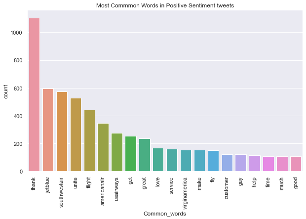

```python
fig, ax = plt.subplots(figsize=(10, 6))
sns.barplot(x='Common_words', y='count',
            data=freq_positive, ax=ax)
plt.title("Most Commmon Words in Positive Sentiment tweets")
plt.xticks(rotation='vertical');
```

#### Finding common words for negative sentiment tweets

```python
#Most common negative words
top = Counter([item for sublist in Negative_sent['text'] for item in sublist])
freq_negative = pd.DataFrame(top.most_common(20))
freq_negative.columns = ['Common_words','count']
freq_negative.style.background_gradient(cmap='flare')
```

|  | Common_words | count |
| --- | --- | --- |
| 0 | flight | 3587 |
| 1 | unite | 2896 |
| 2 | usairways | 2374 |
| 3 | americanair | 2089 |
| 4 | get | 1519 |
| 5 | southwestair | 1214 |
| 6 | hour | 1104 |
| 7 | jetblue | 1051 |
| 8 | cancel | 915 |
| 9 | delay | 898 |
| 10 | customer | 774 |
| 11 | service | 768 |
| 12 | time | 739 |
| 13 | call | 688 |
| 14 | hold | 674 |
| 15 | wait | 668 |
| 16 | help | 664 |
| 17 | bag | 657 |
| 18 | plane | 594 |
| 19 | go | 570 |

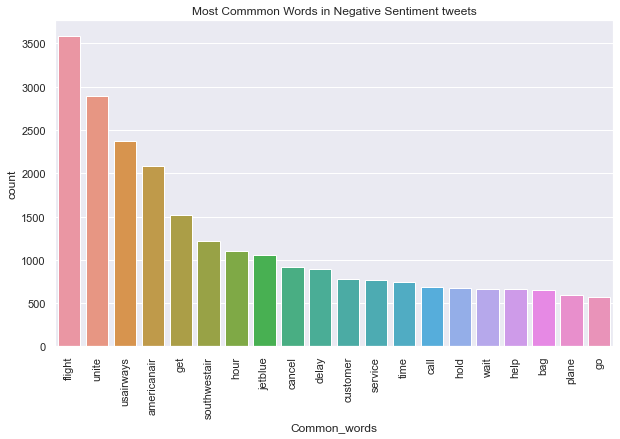

```python
fig, ax = plt.subplots(figsize=(10, 6))
sns.barplot(x='Common_words', y='count',
            data=freq_negative, ax=ax)
plt.title("Most Commmon Words in Negative Sentiment tweets")
plt.xticks(rotation='vertical');
```

#### Positive sentiment WordCloud

```python
def show_wordcloud(Positive_sent, title):
    text = ' '.join(Positive_sent['text'].astype(str).tolist())
    stopwords = set(wordcloud.STOPWORDS)

    fig_wordcloud = wordcloud.WordCloud(stopwords=stopwords,background_color='white',
                    colormap='viridis', width=800, height=600).generate(text)

    plt.figure(figsize=(14,11), frameon=True)
    plt.imshow(fig_wordcloud)
    plt.axis('off')
    plt.title(title, fontsize=30)
    plt.show()
```

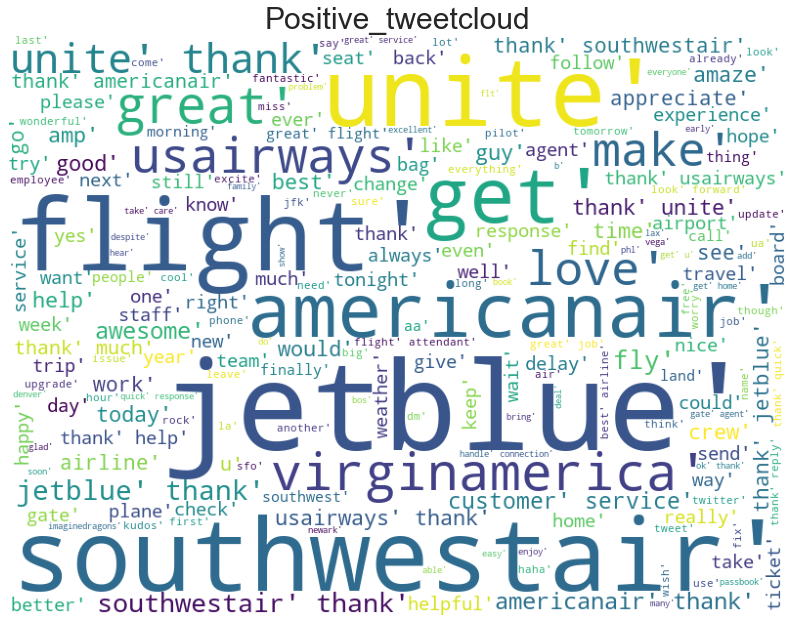

```python
show_wordcloud(Positive_sent, "Positive_tweetcloud")
```

#### Negative sentiment WordCloud

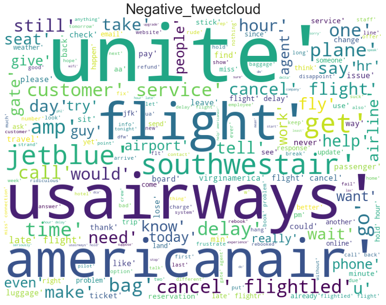

```python
show_wordcloud(Negative_sent, "Negative_tweetcloud")
```

### Model Building

```python
#Normalize and Join words
data['text'] = data.apply(lambda row: normalize(row['text']), axis=1)
data.head()
```

|  | airline_sentiment | airline_sentiment_confidence | negativereason | negativereason_confidence | airline | retweet_count | text | tweet_created | tweet_location | user_timezone | year | month | dates | hour |
| --- | --- | --- | --- | --- | --- | --- | --- | --- | --- | --- | --- | --- | --- | --- |
| 0 | neutral | 1.0000 | NaN | NaN | Virgin America | 0 | virginamerica dhepburn say | 2015-02-24 11:35:52-08:00 | NaN | Eastern Time (US & Canada) | 2015 | 2 | 24 | 11 |
| 1 | positive | 0.3486 | NaN | 0.0000 | Virgin America | 0 | virginamerica plus add commercial experience tacky | 2015-02-24 11:15:59-08:00 | NaN | Pacific Time (US & Canada) | 2015 | 2 | 24 | 11 |
| 2 | neutral | 0.6837 | NaN | NaN | Virgin America | 0 | virginamerica today must mean need take another trip | 2015-02-24 11:15:48-08:00 | Lets Play | Central Time (US & Canada) | 2015 | 2 | 24 | 11 |
| 3 | negative | 1.0000 | Bad Flight | 0.7033 | Virgin America | 0 | virginamerica really aggressive blast obnoxious entertainment guest face amp little recourse | 2015-02-24 11:15:36-08:00 | NaN | Pacific Time (US & Canada) | 2015 | 2 | 24 | 11 |
| 4 | negative | 1.0000 | Can't Tell | 1.0000 | Virgin America | 0 | virginamerica really big bad thing | 2015-02-24 11:14:45-08:00 | NaN | Pacific Time (US & Canada) | 2015 | 2 | 24 | 11 |

#### Building the model based on CountVectorizer and Random Forest

```python
# Vectorization (Convert text data to numbers).
from sklearn.feature_extraction.text import CountVectorizer

bow_vec = CountVectorizer(max_features=2000)                # Keep only 2000 features as number of features will increase the processing time.
data_features = bow_vec.fit_transform(data['text'])

data_features = data_features.toarray()                        # Convert the data features to array.
```

```python
data_features.shape
```

```
(14604, 2000)
```

```python
labelencoder = LabelEncoder()
data['airline_sentiment'] = labelencoder.fit_transform(data['airline_sentiment'])
labels = data["airline_sentiment"]
labels = labels.astype('int')
labels.shape
```

```
(14604,)
```

```python
labels.head()
```

```
0    1
1    2
2    1
3    0
4    0
Name: airline_sentiment, dtype: int32
```

```python
# Split data into training and testing set.

from sklearn.model_selection import train_test_split

X_train, X_test, y_train, y_test = train_test_split(data_features, labels, test_size=0.3, random_state=42)
```

```python
# Using Random Forest to build model for the classification of reviews.
# Also calculating the cross validation score.

from sklearn.ensemble import RandomForestClassifier
from sklearn.model_selection import cross_val_score

forest = RandomForestClassifier(n_estimators=10, n_jobs=4)

forest = forest.fit(X_train, y_train)

print(forest)

print(np.mean(cross_val_score(forest, data_features, labels, cv=10)))
```

```
RandomForestClassifier(n_estimators=10, n_jobs=4)
0.7041207467206736
```

#### Optimizing the parameter: Number of trees in the random forest model(n_estimators)

```python
# Finding optimal number of base learners using k-fold CV ->
base_ln = [x for x in range(1, 25)]
base_ln
```

```
[1,
 2,
 3,
 4,
 5,
 6,
 7,
 8,
 9,
 10,
 11,
 12,
 13,
 14,
 15,
 16,
 17,
 18,
 19,
 20,
 21,
 22,
 23,
 24]
```

```python
# K-Fold Cross - validation .
cv_scores = []
for b in base_ln:
    clf = RandomForestClassifier(n_estimators = b)
    scores = cross_val_score(clf, X_train, y_train, cv = 5, scoring = 'accuracy')
    cv_scores.append(scores.mean())
```

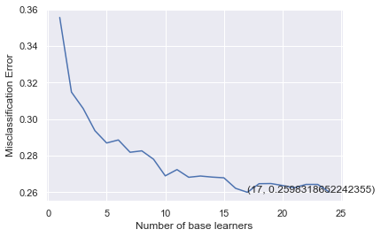

```python
# plotting the error as k increases
error = [1 - x for x in cv_scores]                                 #error corresponds to each nu of estimator
optimal_learners = base_ln[error.index(min(error))]                #Selection of optimal nu of n_estimator corresponds to minimum error.
plt.plot(base_ln, error)                                           #Plot between each nu of estimator and misclassification error
xy = (optimal_learners, min(error))
plt.annotate('(%s, %s)' % xy, xy = xy, textcoords='data')
plt.xlabel("Number of base learners")
plt.ylabel("Misclassification Error")
plt.show()
```

```python
# Training the best model and calculating accuracy on test data .
clf = RandomForestClassifier(n_estimators = optimal_learners)
clf.fit(X_train, y_train)
clf.score(X_test, y_test)
```

```
0.7489730716567777
```

```python
result =  clf.predict(X_test)
```

```
[[2434  267   95]
 [ 372  423   90]
 [ 166  110  425]]
0.7489730716567777
```

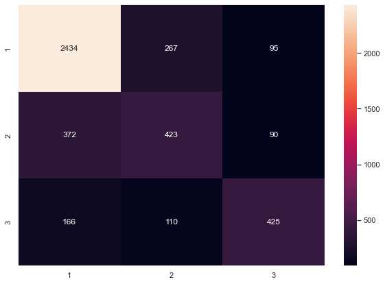

```python
# Print and plot Confusion matirx to get an idea of how the distribution of the prediction is, among all the classes.
from sklearn import metrics
from sklearn.metrics import confusion_matrix

conf_mat = confusion_matrix(y_test, result)

print(conf_mat)

print(metrics.f1_score(y_test, result,average='micro'))

df_cm = pd.DataFrame(conf_mat, index = [i for i in "123"],
                  columns = [i for i in "123"])
plt.figure(figsize = (10,7))
sns.heatmap(df_cm, annot=True, fmt='g')
```

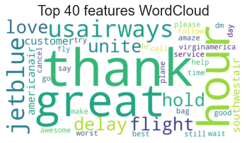

```python
all_features = bow_vec.get_feature_names()              #Instantiate the feature from the vectorizer
top_features=''                                            # Addition of top 40 feature into top_feature after training the model
feat=clf.feature_importances_
features=np.argsort(feat)[::-1]
for i in features[0:40]:
    top_features+=all_features[i]
    top_features+=' '

from wordcloud import WordCloud
wordcloud = WordCloud(background_color="white",colormap='viridis',width=2000,
                          height=1000).generate(top_features)

# Display the generated image:
plt.imshow(wordcloud, interpolation='bilinear')
plt.figure(1, figsize=(14, 11), frameon='equal')
plt.title('Top 40 features WordCloud', fontsize=20)
plt.axis("off")
plt.show()
```

#### Term Frequency(TF) - Inverse Document Frequency(IDF)

```python
# Using TfidfVectorizer to convert text data to numbers.

from sklearn.feature_extraction.text import TfidfVectorizer

vectorizer = TfidfVectorizer(max_features=2000)
data_features = vectorizer.fit_transform(data['text'])

data_features = data_features.toarray()

data_features.shape
```

```
(14604, 2000)
```

```python
# Split data into training and testing set.

from sklearn.model_selection import train_test_split

X_train, X_test, y_train, y_test = train_test_split(data_features, labels, test_size=0.3, random_state=42)
```

```python
# Using Random Forest to build model for the classification of reviews.
# Also calculating the cross validation score.

from sklearn.ensemble import RandomForestClassifier
from sklearn.model_selection import cross_val_score

import numpy as np

forest = RandomForestClassifier(n_estimators=10, n_jobs=4)

forest = forest.fit(X_train, y_train)

print(forest)

print(np.mean(cross_val_score(forest, data_features, labels, cv=5)))
```

```
RandomForestClassifier(n_estimators=10, n_jobs=4)
0.6787178344815296
```

```python
# K - Fold Cross Validation .
cv_scores = []
for b in base_ln:
    clf = RandomForestClassifier(n_estimators = b)
    scores = cross_val_score(clf, X_train, y_train, cv = 5, scoring = 'accuracy')
    cv_scores.append(scores.mean())
```

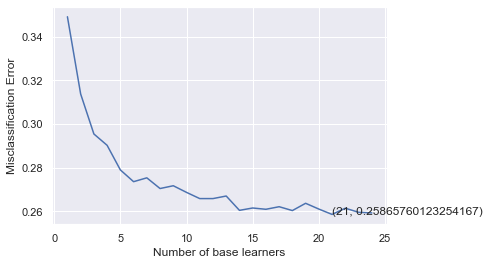

```python
# plotting the error as k increases
error = [1 - x for x in cv_scores]                                              #error corresponds to each nu of estimator
optimal_learners = base_ln[error.index(min(error))]                             #Selection of optimal nu of n_estimator corresponds to minimum error.
plt.plot(base_ln, error)                                                        #Plot between each nu of estimator and misclassification error
xy = (optimal_learners, min(error))
plt.annotate('(%s, %s)' % xy, xy = xy, textcoords='data')
plt.xlabel("Number of base learners")
plt.ylabel("Misclassification Error")
plt.show()
```

```python
# Training the best model and calculating error on test data .
clf = RandomForestClassifier(n_estimators = optimal_learners)
clf.fit(X_train, y_train)
clf.score(X_test, y_test)
```

```
0.7644910999543587
```

```python
result = clf.predict(X_test)
```

```
[[2610  135   51]
 [ 457  361   67]
 [ 227   95  379]]
0.7644910999543587
```

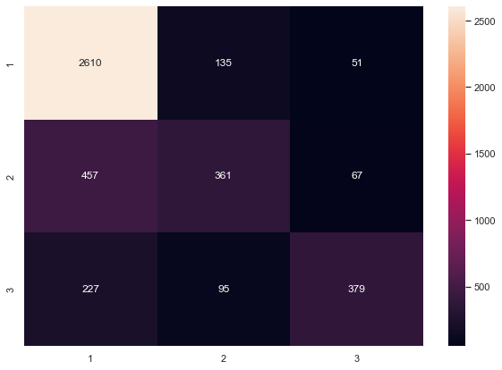

```python
# Print and plot Confusion matirx to get an idea of how the distribution of the prediction is, among all the classes.
result =  clf.predict(X_test)

from sklearn import metrics
from sklearn.metrics import confusion_matrix

conf_mat = confusion_matrix(y_test, result)

print(conf_mat)

print(metrics.f1_score(y_test, result,average='micro'))

df_cm = pd.DataFrame(conf_mat, index = [i for i in "123"],
                  columns = [i for i in "123"])
plt.figure(figsize = (10,7))
sns.heatmap(df_cm, annot=True, fmt='g')
```

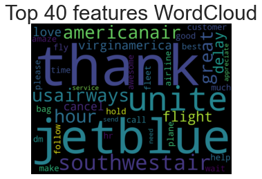

```python
all_features = vectorizer.get_feature_names()                                #Instantiate the feature from the vectorizer
Top_features=''                                                              #Addition of top 40 feature into top_feature after training the model
feat=clf.feature_importances_
features=np.argsort(feat)[::-1]
for i in features[0:40]:
    Top_features+=all_features[i]
    Top_features+=' '


from wordcloud import WordCloud
wordcloud = WordCloud(background_color="Black",width=1000,
                          height=750).generate(Top_features)

# Display the generated image:
plt.imshow(wordcloud, interpolation='bilinear')
plt.figure(1, figsize=(30, 30), frameon='equal')
plt.title('Top 40 features WordCloud', fontsize=30)
plt.axis("off")
plt.show()
```

### Summary:

- A dataset containing reviews in text format and their sentiment with positive, negative, and neutral values was used.
- The goal was to build a model for text-classification.
- The data was pre-processed using various techniques and libraries.
- A Word Cloud plot based on negative and positive sentiments was created.
- The pre-processed data was converted to numbers (vectorized), for model input.
- The model was trained and the parameters were optimized, which increased overall accuracy.
- After building the classification model, the results for the test data were predicted.
- Considering how text classification models perform, the model performed well after using the above techniques.
- The model can be further improved by increasing the max_feature parameter in the vectorizer.
- Term Frequency(TF) - Inverse Document Frequency(IDF) produced better classification
- Other model tuning and hyperparameter tuning techniques can be performed, as well as other pre-processing techniques to further increase the overall accuracy.